Senior Thesis · University of Delaware

# Stereotypes & Hate Speech in Conflict Discourse

A psycholinguistic analysis of implicit bias in tweets from 50+ political influencers before and after October 7, 2023 — using BERT embeddings, word2vec, and the Word Embedding Association Test (WEAT).

[Full Thesis](https://drive.google.com/file/d/1CidLbhxRulkqy-qBkN1-FLi34bgl32X5/view?usp=sharing) [Data Overview](https://blaketrn.notion.site/A-Psycholinguistic-Analysis-Of-Changes-In-Stereotypes-And-Hate-Speech-Associated-With-Muslim-And-Or--1beb8fab88a7800998a1db848f6e43c9)

50+

Influencer accounts

2

Corpora (pre / post Oct 7)

8

Stereotype categories

Research Question

Did implicit stereotypes about Muslim/Arab and Israeli/Jewish groups shift in political discourse following the Hamas attack on October 7, 2023?

Stereotype categories — drawn from Kurdi et al. (2019) — span warmth, coldness, competence, and incompetence, applied across group pairs using cosine-similarity-based WEAT association scores (Caliskan et al., 2017).

Stage 01

Data Collection

Selenium + BeautifulSoup scraper targeting X's advanced search with keyword filtering and engagement thresholds.

Annotated code

Stage 02

Parsing & Cleaning

HTML extraction, emoji/URL removal, keyword validation, and deduplication pipeline.

Live demo

Stage 03

Tokenization

BERT WordPiece tokenizer with stopword removal, sentence segmentation, and token/segment ID generation.

Live demo

Stage 04

Embeddings

BERT contextual 768-dim embeddings and word2vec vectors, chunked per subject for downstream WEAT.

Visualization

Stage 05

SADCAT Dictionary

Semi-automated stereotype dictionary built from WordNet synonyms, antonyms, and SCM theory — used as WEAT attribute sets.

Data resource

Stage 06

Linear Modeling

Hierarchical linear mixed models (lmer) examining bipartisan trends in sentiment and stereotype language over time.

R + plots

Stage 07

WEAT Analysis

Real results

Stage 08

Discussion

Interpretation of findings, bipartisan differences, limitations, and future research directions.

Findings

Stage 01 · MINVERA_AdvancedScrape_X.ipynb

Data Collection

Selenium automates login and X's advanced search across 365 daily windows per account. Rate-limit handling, retry logic, and keyword-group rotation are built in.

Approach

Advanced Search + Keyword Filtering

Each account queried across daily windows using three keyword groups. Min 1,000 faves threshold filters for high-engagement content only.

Anti-rate-limit strategy

Adaptive sleep + retry

Sleeps 3 min every 10 searches. On Retry button detection, waits 10 min and re-attempts. Unprocessed accounts logged for re-runs.

Keyword Groups

GROUP A · Geopolitical entities

Gaza*Israel*West BankPalestin*Jew*Muslim*Islam*Middle East*

GROUP B · Actors & events

HamasNetanyahuGenocideCeasefireTerroris*SinwarIDFIOF

GROUP C · Conflict terms

JihadAntisemiti*Zionis*RafahBen-GvirGallantKhan Younis

# Per account, per day — three keyword group passes search_query.send_keys( f'{keyword1} {hashtags} (from:@{profile})' f' min_faves:1000 until:{until} since:{since}' f' -filter:links -filter:replies' ) search_results = driver.find_element( By.CSS_SELECTOR, '[aria-label="Timeline: Search timeline"]' ) tweets_dict_US[profile].append(search_results.get_attribute('innerHTML'))

Stage 02 · Parsing_Script_for_Raw_HTML.ipynb

Parsing & Cleaning

BeautifulSoup extracts tweet text and engagement metrics from raw innerHTML. A multi-step cleaning function strips emojis, URLs, HTML artifacts, and non-ASCII characters before keyword validation and CSV export.

live demoText cleaning pipeline — remove_extras()

Metrics extracted

·

**Likes, replies, retweets, views** — from aria-label attributes on engagement divs

·

**Timestamp** — from <time> datetime ISO attribute

·

**Tweet text** — from data-testid="tweetText"

Quality filters

·

**37 keyword patterns** must match (regex)

·

**Deduplication** — exact text matches discarded

·

**Likes > 1,000** engagement threshold

Stage 03 · Generating Tokens Details.ipynb

Tokenization

Cleaned tweets pass through a five-step preprocessing pipeline then are tokenized with BERT's WordPiece tokenizer (bert-base-uncased). Each sentence gets [CLS]/[SEP] markers, token IDs, and segment IDs.

live demoBERT tokenization pipeline

Stage 04 · BERT - Getting Embeddings.ipynb

Embedding Generation

BERT (bert-base-uncased) generates 768-dimensional contextual embeddings per token. Sequences exceeding 512 tokens are chunked with re-injected [CLS]/[SEP] markers. Outputs exported per Subject_ID for WEAT analysis.

BERT architecture

12-layer transformer

·

30,522 token vocabulary

·

768-dim hidden states (last layer)

·

12 attention heads per layer

·

Max 512 token sequence length

Processing strategy

Chunk + export per subject

·

All tokens per subject_id concatenated

·

Split into 512-token windows, CLS/SEP re-injected at boundaries

·

Special tokens excluded from final output vectors

# Chunk, embed, exclude special tokens for chunk_tokens, chunk_ids, chunk_segs in chunk_long_sequences( all_tokens, all_token_ids, all_segment_ids, max_length=512 ): with torch.no_grad(): outputs = model(torch.tensor([chunk_ids]), torch.tensor([chunk_segs])) hidden = outputs.last_hidden_state.squeeze(0) for j, (tok, emb) in enumerate(zip(chunk_tokens, hidden)): if tok in ['[CLS]', '[SEP]']: continue results.append({'Token': tok, 'Embedding': emb.numpy().tolist()})

Embedding space visualization

The 768-dimensional BERT vectors are projected to 2D via t-SNE to reveal geometric structure. Words with similar meanings and usage patterns cluster together — the WEAT exploits this by measuring cosine distance from target group clusters to the attribute clusters.

[interactive chart not shown]

Stage 05 · Create Dictionary/Data compiling.ipynb

SADCAT Stereotype Dictionary

The WEAT requires predefined attribute word sets for each SCM dimension. Rather than using an off-the-shelf dictionary, we built one using a modified SADCAT pipeline (Nicolas et al., 2019; 2021) — expanding seed words through WordNet synonym, antonym, hyponym, and hypernym traversal, then lemmatizing and deduplicating to produce four attribute lists: Warm, Cold, Competent, Incompetent.

### Theoretical Grounding — Stereotype Content Model (SCM)

Fiske et al. (2002) proposed the SCM, which posits that all stereotypes convey two primary dimensions — **warmth** and **competence**. The warmth dimension attributes sociability and morality; the competence dimension attributes intelligence, independence, and capability.

Consistent with early SCM work, Jewish, Turkish, Arabic, and Middle Eastern people are regarded as having low warmth (LW) and low competence (LC) compared to white Americans — with the sole exception of high competence (HC) attributed to Jewish people (Fiske et al., 2002; Lee & Fiske, 2006; Cuddy et al., 2007).

The BIAS Map (Cuddy et al., 2007) translates stereotypical content to real-life actions: *envied groups* (LW, HC) elicit passive facilitation and active harm (e.g., harassment); *hated groups* (LW, LC) elicit both passive harm (e.g., dismissal, inaction) and active harm. In this framework, Jewish people receive active harm yet passive facilitation, while Middle Eastern ethnic groups receive both types of harm.

### Figure 1 — Fiske et al. (2002) SCM: Perceived Warmth & Competence of Social Groups

The Stereotype Content Model positions social groups along two axes — **warmth** (sociability, morality) and **competence** (intelligence, capability). Each quadrant predicts a distinct emotional and behavioural response. Groups studied in the present thesis are highlighted.

[figure not shown]

Figure 1. Stereotype Content Model (SCM) quadrant adapted from Fiske et al. (2002). Groups highlighted in red are the focus of the present analysis. Position reflects perceived warmth (x-axis) and competence (y-axis) relative to the American in-group.

Pipeline overview

Seed → WordNet expansion → Deduplication

1.

Load seed words per SCM category from `Raw_vocab_dictionary.csv`

2.

**get_synonyms()** — traverses synsets for hypernyms, hyponyms, holonyms, meronyms, similar-tos, and derivatives (adjective pos only: a, s, r)

3.

**get_antonyms()** — traverses lemma antonyms across all synsets for cross-dimension enrichment

4.

Antonyms of Warm → added to Cold; antonyms of Cold → added to Warm; same for Competence ↔ Incompetence

5.

Lemmatize all words with NLTK WordNetLemmatizer, deduplicate, export to JSON

WordNet relations used

Multi-relation graph traversal

·

**Hypernyms** — broader category (e.g., "kind" → "good")

·

**Hyponyms** — narrower category (e.g., "warm" → "lukewarm")

·

**Holonyms / Meronyms** — part-whole relationships

·

**Similar-tos** — adjective similarity clusters

·

**Antonyms** — used for cross-dimension seeding

·

**Derivatives** — syntactic marker forms via lemma traversal

sampleExcerpt — SADCAT stereotype dictionary (Stereotype_Dictionary.json)

Competent

Incompetent

Warm

Cold

# get_synonyms() — WordNet multi-relation traversal (adjectives only) for syn in wordnet.synsets(text): for hypernym in syn.hypernyms(): if hypernym.pos() in ["a", "s", "r"]: # adj / adj-sat / adv new.append(hypernym.name().split(".")[0]) for similar in syn.similar_tos(): if similar.pos() in ["a", "s", "r"]: new.append(similar.name().split(".")[0]) # ... also hyponyms, holonyms, meronyms, derivatives # Cross-dimension seeding: antonyms of Warm → added to Cold if row["Category"] == "Warm": warm_antonyms = get_antonyms(row["Synonyms"]) word_dict["Warm"].extend(row["Synonyms"]) word_dict["Cold"].extend(warm_antonyms) # antonyms of Warm seed Cold word_dict["Warm"].extend(cold_antonyms) # antonyms of Cold seed Warm # Deduplicate word_dict["Warm"] = list(set(word_dict["Warm"]))

ℹ The SADCAT script was originally written in R (Nicolas et al., 2019). This implementation is a Python adaptation developed by Gautam et al. (under review), further modified for this study. Seed categories follow Kurdi et al. (2019): Warm, Cold, Competence, Incompetence, Jewish, Muslim, Arabic, Israeli.

Stage 06 · R Codes/Finalizing_models.R

Linear Hierarchical Modeling

Hierarchical linear mixed models (lmer) were fitted to examine how bipartisan language changed over time relative to the conflict. Political affiliation, ethnorace/militant group, and date index were fixed effects; Subject_ID was a random intercept to account for repeated influencer observations.

Model structure

Four-way interaction (simplified random effects)

·

**Outcomes:** tone_neg, tone_pos, prop_Warm, prop_Cold, prop_Competence, prop_Incompetence, Hate_Score

·

**Fixed effects:** Ethnorace × Affiliation_Contrast × Date_Index (× Civilian for sentiment models)

·

**Random intercept:** (1|Subject_ID) — simplified from full random-slope models due to convergence

·

**Interaction decomposition:** significant interactions decomposed using get_simslopes.R (Gautam, under review)

Key contrasts

Ethnorace · Militant · Date_Index

·

**Ethnorace:** −0.5 = more Israeli/Jewish; +0.5 = more Arabic/Muslim

·

**Militant:** −0.5 = more IDF; +0.5 = more Hamas (post-conflict only)

·

**Date_Index:** days from Oct 7, 2023 (negative = before, positive = after)

·

**Affiliation_Contrast:** right-leaning vs. left-leaning political influencers

# Contrast coding & date indexing data_pre <- read.csv("Before_Stereotypes_Proportion_LIWC_Hate.csv") %>% mutate(Condition_Contrast = -0.5) %>% create_date_numbering("Before_Dates", "2023-10-06", direction = "backward") data <- data %>% mutate(Militant = ifelse(prop_IDF > prop_Hamas, -0.5, ifelse(prop_Hamas > prop_IDF, 0.5, NA))) # Competence stereotype model mod_compstereotype = lmer(prop_Competence ~ Militant*Affiliation_Contrast*Date_Index + (1|Subject_ID), data = data) summary(mod_compstereotype)

### Figure 1 — Negative Sentiment: IDF vs. Hamas over time

There was no significant difference in how negative sentiment was used to discuss IDF and Hamas for **left-leaning influencers** as the conflict progressed.

For **right-leaning influencers**, there was a significant increase in negative sentiment when discussing the IDF (blue dashed line, left panel) — contrasting with how Hamas was discussed (green line, flat). This suggests right-leaning influencers increasingly used negative language about the IDF over the conflict, possibly reflecting internal political tensions or reactions to IDF military operations.

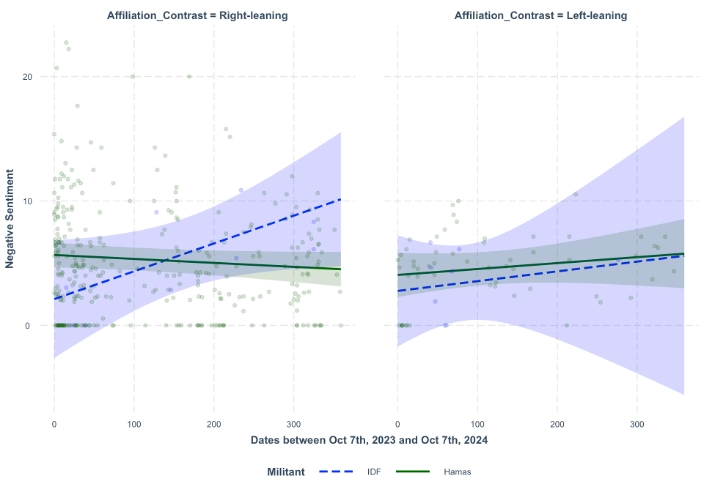

Figure 1. Significant difference in negative sentiment for right-leaning influencers discussing IDF vs. Hamas (Oct 7, 2023 – Oct 7, 2024).

### Figure 2 — Competence words: Israeli/Jewish group before and after Oct 7

When discussing Israeli and/or Jewish people, there is a strong bipartisan difference in competence stereotype use throughout the conflict.

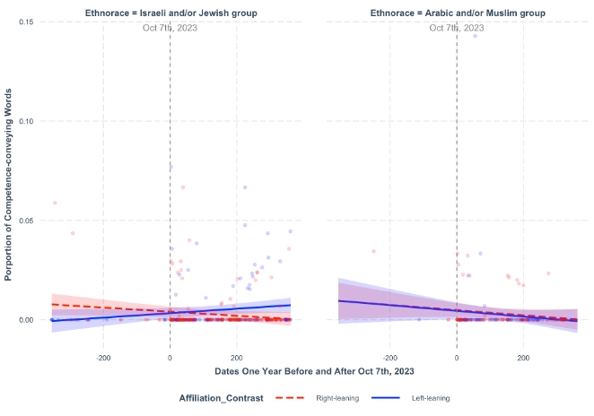

Figure 2. Significant bipartisan difference in competence-conveying words towards the Israeli and/or Jewish group.

### Figure 3 — Competence words: IDF vs. Hamas (post-conflict only)

ⓘ IDF was absent from the pre-conflict corpus; no pre-conflict modeling was performed for this group.

For IDF tweets (left panel), **left-leaning influencers** showed an increasing competence trend (blue line), while **right-leaning influencers** decreased (red dashed) — a significant crossed interaction. For Hamas (right panel), both affiliations showed minimal and flat competence language. Hamas was mentioned far more than IDF (n<sub>Hamas</sub> = 375 vs. n<sub>IDF</sub> = 17).

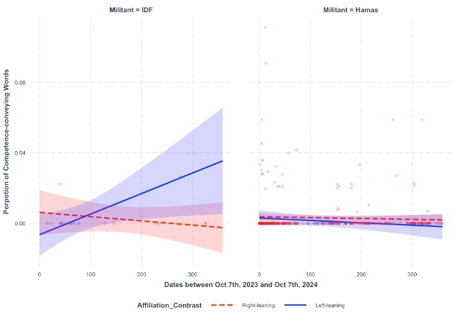

Figure 3. Significant bipartisan difference in competence-conveying words towards the IDF (post-conflict only).

### Figure 4 — Incompetence words: IDF vs. Hamas (post-conflict only)

ⓘ IDF was absent from the pre-conflict corpus; no pre-conflict modeling was performed for this group.

The incompetence pattern mirrors Figure 3 in a crossed trajectory. For IDF (left panel), **left-leaning influencers** increased incompetence-conveying language over time, while **right-leaning influencers** decreased. Despite these significant crossed effects, it was hard to discern whether the differences reflect broad trends or the subjective appraisal of a small number of influencers, given the low IDF mention count.

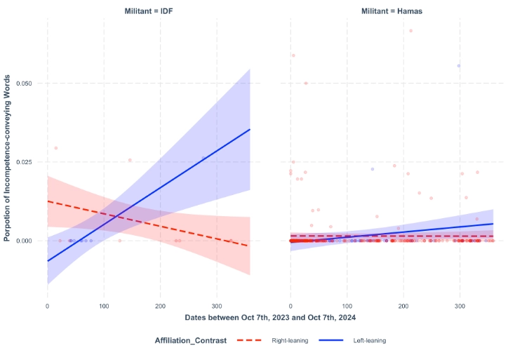

Figure 4. Significant bipartisan difference in incompetence-conveying words towards the IDF (post-conflict only).

Stage 07 · WEAT.ipynb · Tables 4–11 from thesis

WEAT Analysis

SC-WEAT and double-category WEAT quantify implicit stereotypes by comparing cosine similarities between target groups and SCM attribute pairs (Warm/Cold, Competence/Incompetence) using permutation testing on BERT embeddings.

⚠ IDF was not mentioned by any influencer in the "Before" period (10/07/22–10/06/23), so SC-WEAT could not be performed for this group pre-conflict. In the "After" period, Hamas was discussed substantially more (n = 375 tweets) compared to IDF (n = 17 tweets).

**Before Oct 7 (Tables 4 & 5):** No significant effects across Israeli, Jewish, Arabic, Muslim groups. IDF and Hamas absent from pre-conflict corpus entirely.

**After Oct 7 (Tables 6 & 7):** All six groups showed significant negative D-scores on both SCM dimensions — cold and incompetent stereotypes applied indiscriminately across all groups in conflict discourse.

How to read these results

D

**D-score (effect size):** A **negative D** means the group's word embeddings are closer to the *cold* or *incompetent* attribute words — i.e. the language around that group carries an implicit association with **low warmth** or **low competence**. A **positive D** means the opposite — closer association with warmth or competence.

p

**Statistical significance:** p < .05 indicates a **statistically significant** effect — the observed D-score is unlikely to be due to chance alone (as confirmed by the permutation test). p ≥ .05 means the result is *not significant* (ns).

sub

**P-value subscripts:** p<sub>left</sub> = one-tailed probability that the D-score is in the left tail; p<sub>right</sub> = one-tailed probability in the right tail; p<sub>tot</sub> = two-tailed total probability (the primary significance criterion used throughout).

SC-WEAT formula

s(w, A, B) = mean_{a∈A} cos(w,a) − mean_{b∈B} cos(w,b) D = mean_{w∈X} s(w,A,B) / std_dev(all similarities)

Permutation test

500–1,000 shuffles

·

Attribute labels randomly reassigned each iteration

·

p<sub>left</sub>, p<sub>right</sub>, p<sub>tot</sub> all reported

·

Significance threshold: p<sub>tot</sub> < .05

Stage 08 · Results interpretation

Discussion

Interpretation of SC-WEAT findings, bipartisan differences in stereotype language, limitations of the study, and directions for future research.

### 3.1 Single-Category WEAT — Key Findings

BERT embeddings found no statistical significance in the effect sizes of all social groups and SCM attribute combinations in the "Before" period. However, in the "After" period, SC-WEAT using BERT vectors revealed highly significant associations of all six target groups with *low warmth* and *low competence*:

Israeli low warmth (D = −0.242; p = .005) and low competence (D = −0.346; p = .004) · IDF low warmth (D = −0.211; p = .012) and low competence (D = −0.339; p = .006) · Jewish low warmth (D = −0.261; p = .003) and low competence (D = −0.348; p = .002) · Arabic low warmth (D = −0.228; p = .006) and low competence (D = −0.340; p = .005) · Hamas low warmth (D = −0.208; p = .01) and low competence (D = −0.319; p = .007) · Muslim low warmth (D = −0.294; p < .001) and low competence (D = −0.360; p = .005).

The study revealed significant, negative consequences of the conflict narrative on social media regarding stereotype and implicit association of the implicated social groups. While there were bipartisan differences in advocacy for international policies regarding the conflict in the Gaza Strip, support and non-support of influencers for Israeli and/or Jewish or Arabic and/or Muslim people were both accompanied by implicit association with low warmth and low competence after the start of the war.

However, it is unclear whether these associations were a natural consequence of the turmoil and distress around wartime, or reflected the influencers' implicit opinions. It is also important to note that these associations cannot be generalized to the larger population in the U.S. that used X around the time of the conflict, as readers' perception or action beyond seeing such tweets are beyond the scope of the study.

### Bipartisan Differences

However, as the conflict progresses, it is difficult to explain how the significant difference in negativity in discussing the IDF compared to Hamas for right-leaning influencers arises. Within the timeline of the conflict, negative sentiment can be diversely utilized in discussions of grief, humanitarian crises, national security concerns, and in critiques of the opposing party's opinions.

In contrast, left-leaning influencers were observed to have a significant difference in their language when discussing the IDF and Hamas in the Competence dimension, where IDF was explicitly regarded as both more competent and incompetent after the start of the conflict. These polarizing opinions can be due to the internal division of the left wing regarding the stance of the U.S. on the conflict (Kamarck et al., 2024).

Since Hamas was discussed more frequently by the influencers in the study (n<sub>Hamas</sub> = 375 vs. n<sub>IDF</sub> = 17), future research should examine the bipartisan differences in how the IDF and Hamas were portrayed with a different group of political influencers.

### Limitations & Future Directions

#### Small corpora & unequal mentions

The study used a limited number of influencers and the natural noise of social data from X, with unequal mentions of all social groups implicated in the conflict.

#### Platform algorithmic bias

Textual data was heavily reliant on results displayed by X's Advanced Search tools and X's own algorithmic bias per platform policy.

#### Computational language lag

Computational methods always lag behind the development of human natural language. More sophisticated measures for topical categorization of tweets should be considered in future work.

#### Cross-platform generalizability

Future research should explore whether these implicit associations were present equally across different social media platforms throughout the timeline of the conflict.

#### Longitudinal scope

More in-depth, extended longitudinal studies of the social groups implicated would offer insights into how stereotype content fluctuates during high and low-tension intergroup contact.

#### IDF / Hamas imbalance

IDF was absent from the pre-conflict corpus entirely, and mentioned only 17 times post-conflict vs. 375 for Hamas. Future studies should use a different influencer sample to better balance these groups.